# Data Exploration

### Explore Runtime

**1. Total Runtime**  
1. What is the distribution of runtime (for the whole study)?  
2. What are the min, max, mean & SD?  
3. Do they follow a normal distribution?

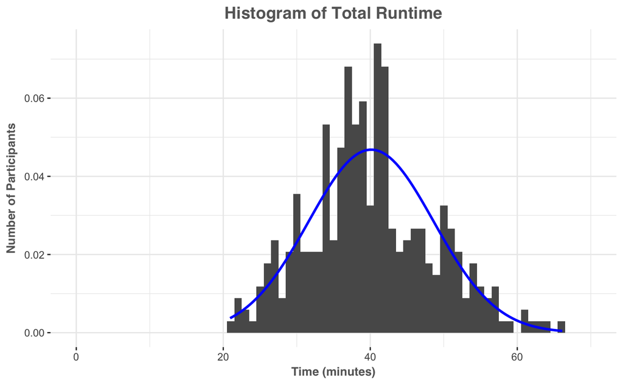

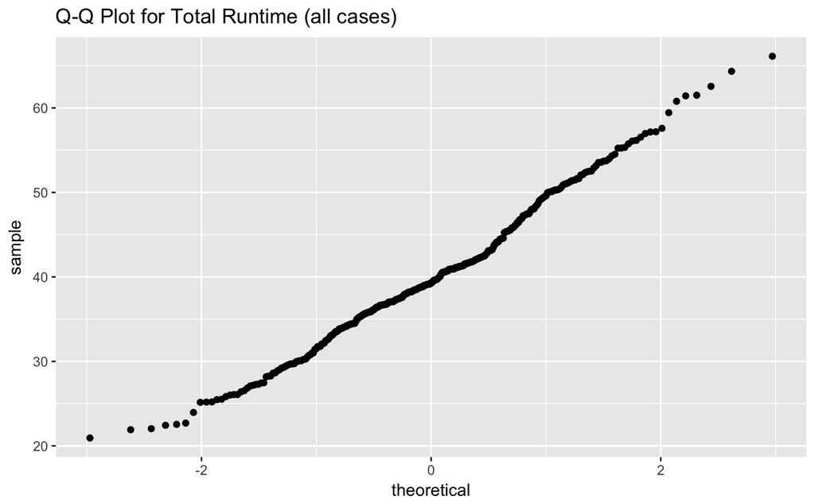

```
participantData$TOTAL_T_M
       n  missing distinct     Info     Mean      Gmd      .05      .10      .25      .50      .75      .90      .95
     338        0      319        1    40.12     9.59    26.51    29.36    34.49    39.28    45.44    51.63    55.24

lowest : 20.93 21.91 22.03 22.43 22.54, highest: 61.43 61.51 62.56 64.34 66.12
```

**Analysis**  
*The mean total runtime was approximately 40 minutes, with a standard deviation of ~ 9 minutes. The fastest person finished in 21 minutes (suspicious) with the longest taking 66 minutes (also suspicious). A Shapiro-Wilk test for normality yielded a value of W = 0.99, 0.01 < p < 0.05, suggesting that the distibution is significantly non-normal, however, the S-W test is known to be biased toward non-normalcy for large samples. The distribution does appear to be slightly positively skewed. Inspection of the QQ-plot reveals that the distribution can be treated as normal for this sample size.*

TODO: EXAMINE OUTLIERS AND CONSIDER FOR EXCLUSION

**2. TOTAL Runtime by Graph Order**  
1. What is the distribution of runtime (for the whole study) for each level of the graph-order factor?  
2. What are the min, max, mean & SD?  
3. Do they follow a normal distribution?

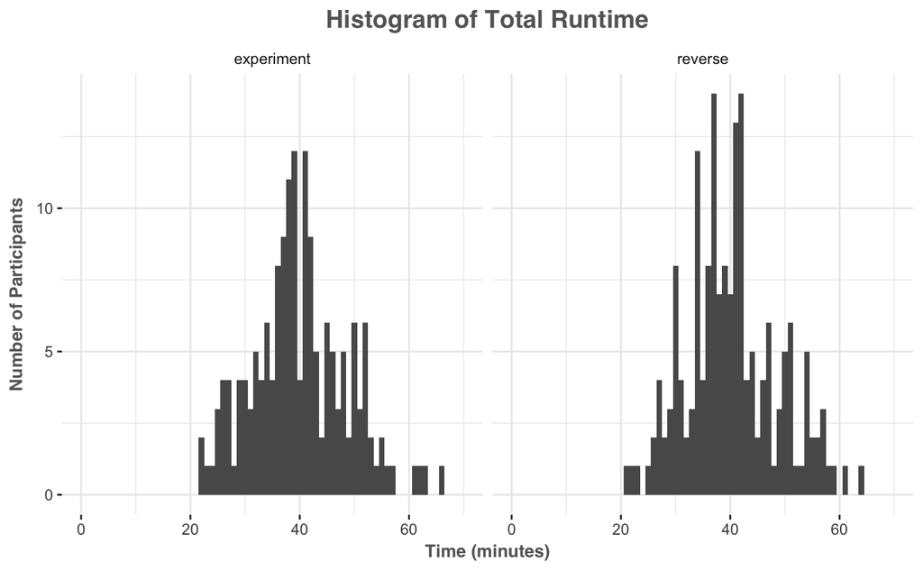

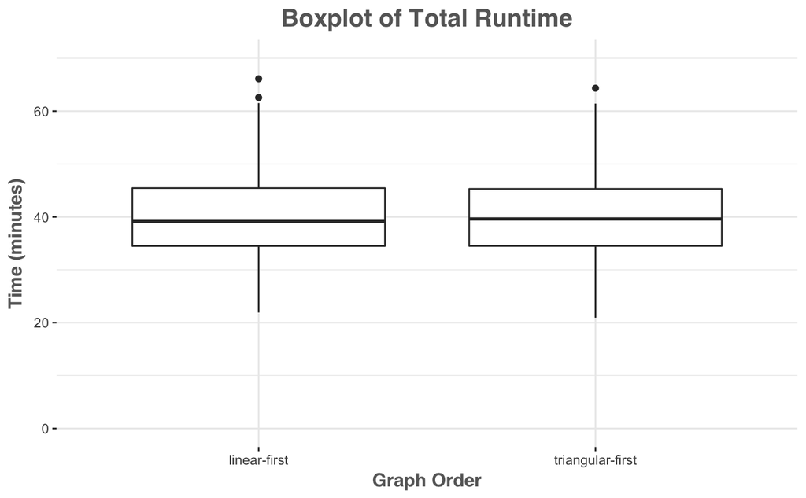

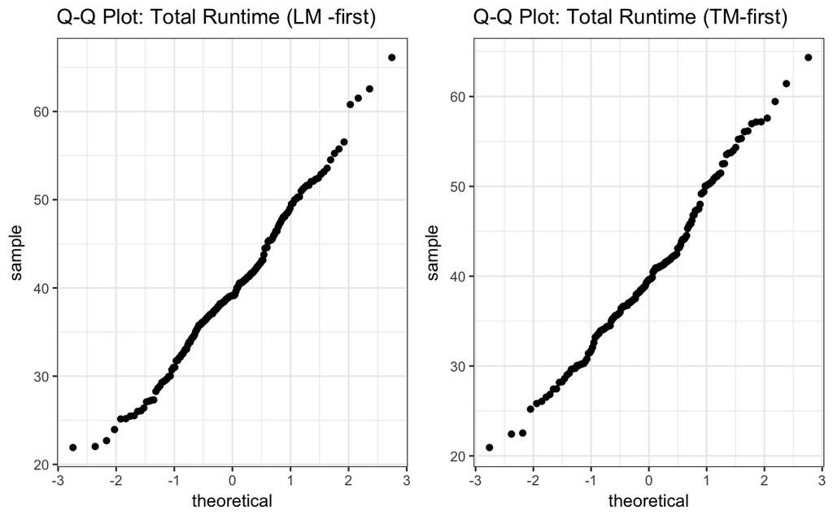

```
participantData$TOTAL_T_M
       n  missing distinct     Info     Mean      Gmd      .05      .10      .25      .50      .75      .90      .95
     338        0      319        1    40.12     9.59    26.51    29.36    34.49    39.28    45.44    51.63    55.24

lowest : 20.93 21.91 22.03 22.43 22.54, highest: 61.43 61.51 62.56 64.34 66.12
participantData$experiment: experiment
dd[x, ]
       n  missing distinct     Info     Mean      Gmd      .05      .10      .25      .50      .75      .90      .95
     165        0      162        1    39.94    9.722    26.02    28.74    34.49    39.14    45.45    51.55    53.49

lowest : 21.91 22.03 22.69 23.95 25.15, highest: 56.54 60.79 61.51 62.56 66.12
--------------------------------------------------------------------------------------------------------
participantData$experiment: reverse
dd[x, ]
       n  missing distinct     Info     Mean      Gmd      .05      .10      .25      .50      .75      .90      .95
     173        0      169        1    40.28    9.507    27.45    29.81    34.50    39.62    45.30    52.29    55.63

lowest : 20.93 22.43 22.54 25.20 25.83, highest: 57.18 57.59 59.44 61.43 64.34
```

**Analysis**  
*The total runtime distributions are similiar for each level of the graph order factor, with the shortest times around 20 minutes and the longest more than 60.*

**3. LINEAR TASK Runtime by Graph Order**  
1. What is the distribution of runtime (for just the linear model task) for each level of the graph-order factor?  
2. What are the min, max, mean & SD?  
3. Do they follow a normal distribution?

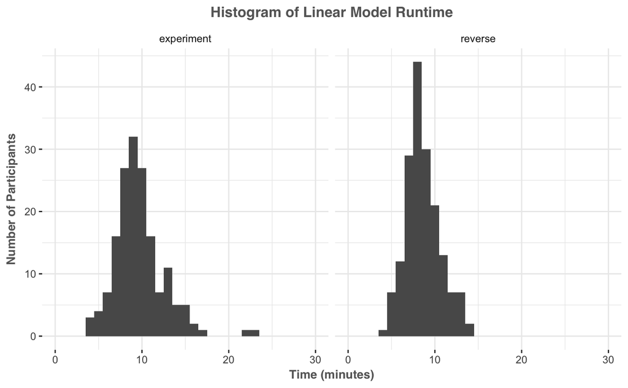

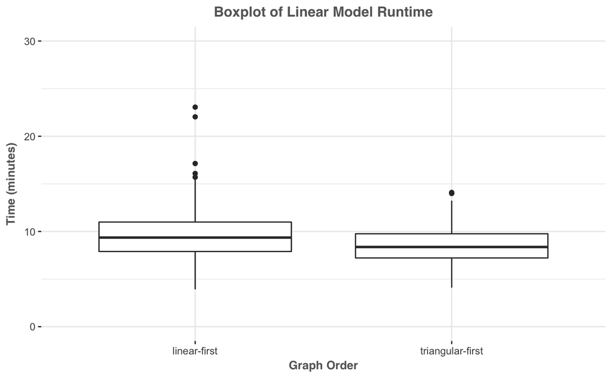

```
participantData$LM_T_M
       n  missing distinct     Info     Mean      Gmd      .05      .10      .25      .50      .75      .90      .95
     338        0      269        1    9.151    2.686    5.684    6.507    7.600    8.825   10.408   12.522   13.303

lowest :  3.92  4.10  4.11  4.23  4.63, highest: 15.70 16.09 17.14 22.04 23.06
participantData$experiment: experiment
dd[x, ]
       n  missing distinct     Info     Mean      Gmd      .05      .10      .25      .50      .75      .90      .95
     165        0      146        1    9.708    3.084    5.832    6.642    7.900    9.360   10.990   13.028   14.544

lowest :  3.92  4.11  4.23  5.25  5.29, highest: 15.70 16.09 17.14 22.04 23.06
--------------------------------------------------------------------------------------------------------
participantData$experiment: reverse
dd[x, ]
       n  missing distinct     Info     Mean      Gmd      .05      .10      .25      .50      .75      .90      .95
     173        0      156        1    8.619    2.194    5.674    6.452    7.220    8.370    9.760   11.324   12.444

lowest :  4.10  4.63  4.75  4.96  5.09, highest: 12.66 12.95 13.24 13.99 14.10
```

**4. TRIANGULAR TASK Runtime by Graph Order**  
1. What is the distribution of runtime (for just the triangular model task) for each level of the graph-order factor?  
2. What are the min, max, mean & SD?  
3. Do they follow a normal distribution?

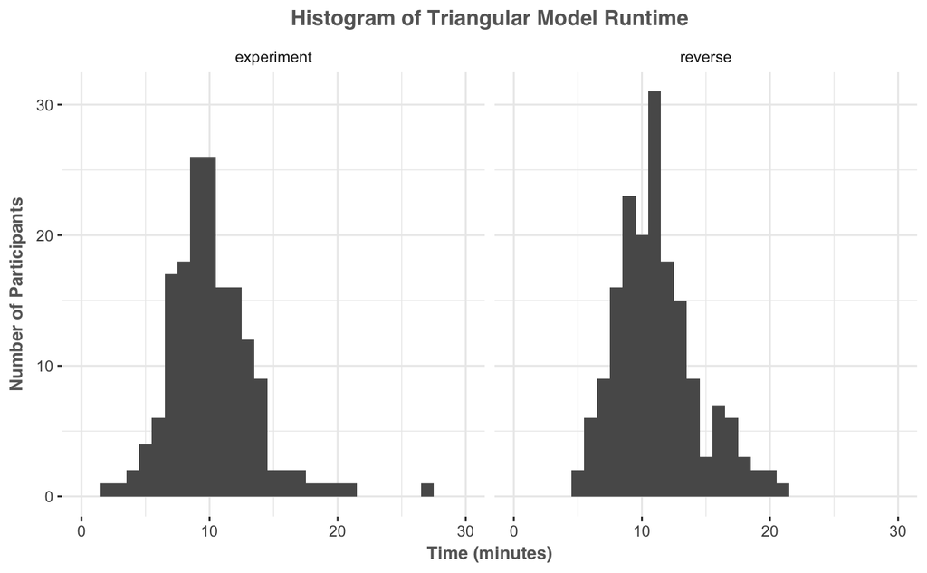

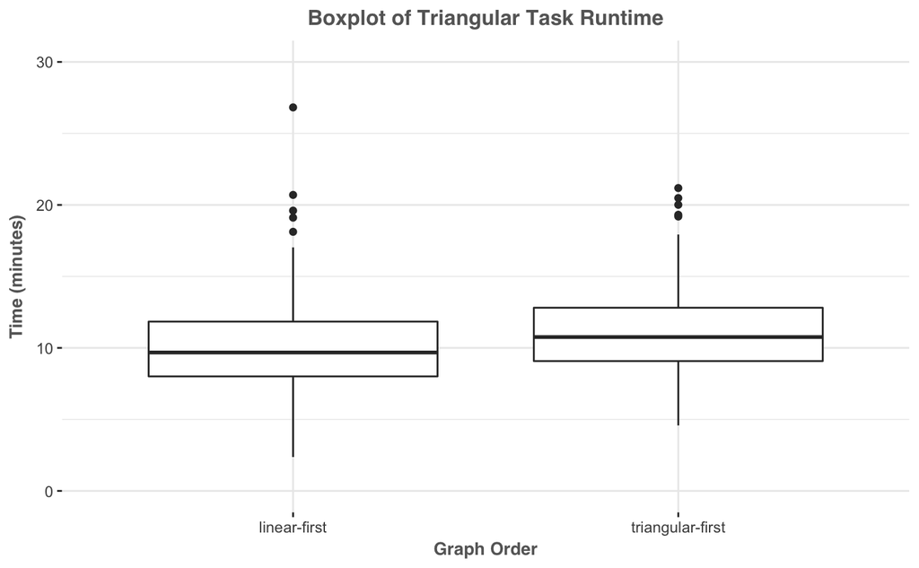

```
participantData$TM_T_M
       n  missing distinct     Info     Mean      Gmd      .05      .10      .25      .50      .75      .90      .95
     338        0      301        1     10.7    3.573    6.109    7.095    8.733   10.250   12.383   14.819   16.783

lowest :  2.37  3.14  3.99  4.35  4.58, highest: 20.01 20.48 20.70 21.18 26.82
participantData$experiment: experiment
dd[x, ]
       n  missing distinct     Info     Mean      Gmd      .05      .10      .25      .50      .75      .90      .95
     165        0      156        1    10.18    3.501    5.776    6.752    8.010    9.680   11.840   13.972   15.486

lowest :  2.37  3.14  3.99  4.35  5.17, highest: 18.12 19.11 19.60 20.70 26.82
--------------------------------------------------------------------------------------------------------
participantData$experiment: reverse
dd[x, ]
       n  missing distinct     Info     Mean      Gmd      .05      .10      .25      .50      .75      .90      .95
     173        0      161        1    11.19    3.561    6.580    7.628    9.080   10.760   12.810   16.168   17.488

lowest :  4.58  5.25  5.54  5.59  5.69, highest: 19.19 19.31 20.01 20.48 21.18
```

[figure not shown]

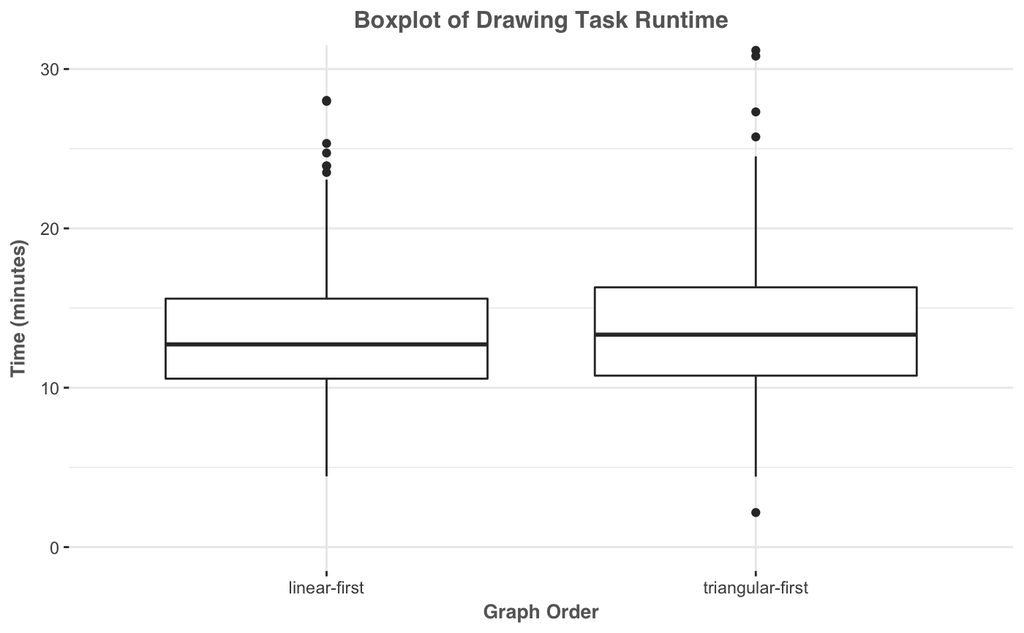

```
participantData$D_T_M
       n  missing distinct     Info     Mean      Gmd      .05      .10      .25      .50      .75      .90      .95
     338        0      304        1    13.76    4.962    7.748    8.751   10.692   13.085   16.095   19.406   22.803

lowest :  2.17  4.42  4.44  4.60  5.72, highest: 27.97 28.03 30.81 31.17 32.13
participantData$experiment: experiment
dd[x, ]
       n  missing distinct     Info     Mean      Gmd      .05      .10      .25      .50      .75      .90      .95
     165        0      159        1    13.49      4.9    7.550    8.496   10.570   12.720   15.590   18.862   22.910

lowest :  4.44  4.60  5.72  5.88  6.28, highest: 24.73 25.33 27.97 28.03 32.13
--------------------------------------------------------------------------------------------------------
participantData$experiment: reverse
dd[x, ]
       n  missing distinct     Info     Mean      Gmd      .05      .10      .25      .50      .75      .90      .95
     173        0      166        1    14.01    5.028    7.838    9.066   10.760   13.330   16.300   20.302   22.754

lowest :  2.17  4.42  7.09  7.21  7.47, highest: 24.52 25.74 27.31 30.81 31.17
```